# Billiards and Tilts Analysis Notebook

Shanaathanan Modchalingam

# 1 Figure 2: Learning Curves

## 1.1 All data

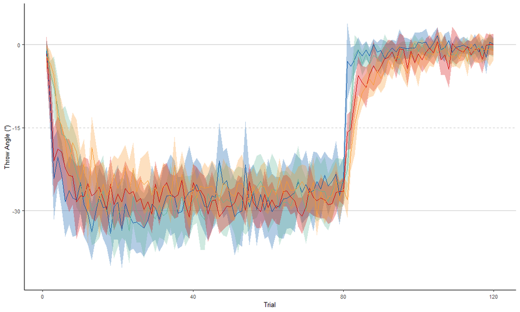

```r
# filter out data
data_per_ppt <- omnibus_df %>%
  filter(
    phase != "transfer",
    trial_num >= 214
  ) %>%
  mutate(
    trial_num = ifelse(
      trial_num >= 335,
      trial_num - 1,
      trial_num
    )
  )

# vars
bl_trial_shift <- 213
num_exps <- 4

# make per_group df
data_per_group <- data_per_ppt %>%
  group_by(experiment, phase, test_type, block_num, trial_num, learning_and_decay_curves) %>%
  summarise(
    mean_deviation = mean(throw_deviation),
    ci_deviation = vector_confint(throw_deviation),
    n = n(),
    .groups = "drop"
  ) %>%
  arrange(experiment, trial_num)

# set up plot
p <- data_per_group %>%
  filter(block_num != 14) %>%
  ggplot(
    aes(
      x = trial_num - bl_trial_shift,
      y = mean_deviation,
      colour = experiment
    )
  ) +
  theme_classic() +
  theme(
    legend.position = "none",
    text = element_text(size = text_size)
  ) +
  labs(
    x = "Trial",
    y = "Throw Angle (°)"
  ) + # add horizontal lines
  geom_hline(
    yintercept = c(0, -30), linewidth = 0.4,
    colour = "#CCCCCC", linetype = "solid"
  ) +
  geom_hline(
    yintercept = c(-15), linewidth = 0.4,
    colour = "#CCCCCC", linetype = "dashed"
  ) + # add vertical lines
  # geom_vline(
  #   xintercept = c(333.5 - bl_trial_shift), linewidth = 0.4,
  #   colour = "#CCCCCC", linetype = "dashed"
  # ) +
  # scale axes
  scale_y_continuous(
    limits = c(-42, 5),
    breaks = c(0, -15, -30),
    labels = c(0, -15, -30)
  ) +
  scale_x_continuous(
    # limits = c(0, 160),
    breaks = c(0, 40, 80, 120, 160),
    labels = c(0, 40, 80, 120, 160)
  ) +
  # add confidence intervals and data points
  geom_ribbon(
    aes(
      ymin = mean_deviation - ci_deviation,
      ymax = mean_deviation + ci_deviation,
      fill = experiment
    ),
    colour = NA, alpha = 0.3
  ) +
  geom_ribbon(
    data = data_per_group %>%
      filter(block_num == 14),
    aes(
      ymin = mean_deviation - ci_deviation,
      ymax = mean_deviation + ci_deviation,
      fill = experiment
    ),
    colour = NA, alpha = 0.3
  ) +
  geom_line() +
  geom_line(
    data = data_per_group %>%
      filter(block_num == 14)
  ) + # set colour palette
  scale_colour_manual(
    values = pallete_list
  ) +
  scale_fill_manual(
    values = pallete_list
  )

# save
if (save_plots) {
  ggsave(
    p,
    filename = "../data/figs/paper_figs/fig2_initial_exps_all.pdf", device = "pdf",
    height = 2, width = 3.75
  )
}

p
```

## 1.2 Phases (used for model fitting)

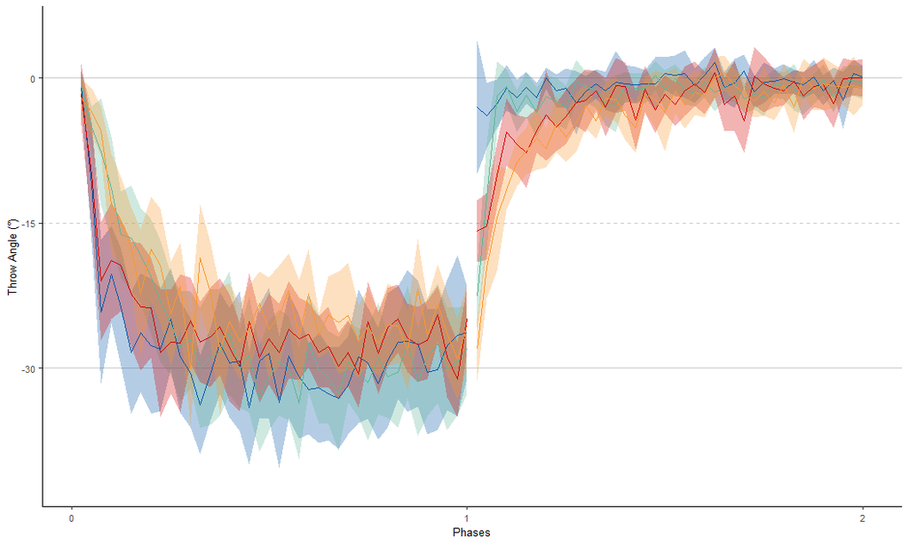

```r
# filter out just the trials of interest
data_per_group <- data_per_group %>%
  filter(
    phase != "other", phase != "transfer",
    learning_and_decay_curves == 1
  )

# add a dummy column with repeating sequence
# NOTE: this can't be combined with above since we are using nrow
data_per_group <- data_per_group %>%
  mutate(dummy_x = rep(1:(nrow(data_per_group) / num_exps),
    length.out = nrow(data_per_group)
  ))

# set up plot
p <- data_per_group %>%
  ggplot(
    aes(
      x = dummy_x, y = mean_deviation, colour = experiment
    )
  ) +
  theme_classic() +
  theme(
    legend.position = "none",
    text = element_text(size = text_size)
  ) +
  labs(
    x = "Phases",
    y = "Throw Angle (°)"
  ) + # add horizontal lines
  geom_hline(
    yintercept = c(0, -30), linewidth = 0.4,
    colour = "#CCCCCC", linetype = "solid"
  ) +
  geom_hline(
    yintercept = c(-15), linewidth = 0.4,
    colour = "#CCCCCC", linetype = "dashed"
  ) + # set colour palette
  scale_colour_manual(values = pallete_list) +
  scale_fill_manual(values = pallete_list) + # scale axes
  scale_y_continuous(
    limits = c(-42, 5),
    breaks = c(0, -15, -30),
    labels = c(0, -15, -30)
  ) +
  scale_x_continuous(
    # limits = c(0, 160),
    breaks = c(0, 40, 80, 120),
    labels = c(0, 1, 2, 3)
  )

# add confidence intervals and data points
for (uniq_phase in unique(data_per_group$phase)) {
  # get the data for this block
  to_plot_data <- filter(data_per_group, phase == uniq_phase)

  p <- p + geom_ribbon(
    data = to_plot_data,
    aes(
      ymin = mean_deviation - ci_deviation,
      ymax = mean_deviation + ci_deviation,
      fill = experiment
    ), colour = NA, alpha = 0.3
  ) + geom_line(
    data = to_plot_data
  )
}

# save
if (save_plots) {
  ggsave(
    p,
    filename = "../data/figs/paper_figs/fig2_initial_exps_phases.pdf", device = "pdf",
    height = 2, width = 3.75
  )
}

p
```

To better compare across all our studies, we normalize all our data using the last 2 trial-sets in the Initial Learning phase.

Note: we can see if each group is different from 1 at the end of training to see if they fully adapted by the end of the Initial Learning phase.

## 1.3 Normalized Training Phases

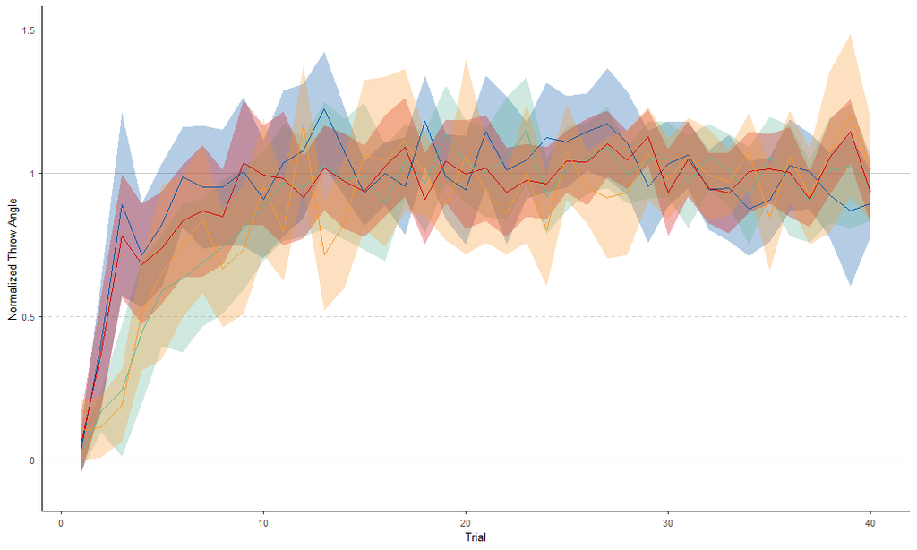

```r
# rest of the exps
data_per_group <- omnibus_df %>%
  filter(
    trial_num >= 214,
    phase == "training",
    learning_and_decay_curves == 1
  ) %>%
  group_by(experiment, phase, test_type, trial_num) %>%
  summarise(
    mean_deviation = mean(norm_throw_deviation),
    ci_deviation = vector_confint(norm_throw_deviation),
    .groups = "drop"
  ) %>%
  arrange(experiment, trial_num)

# add a dummy column with repeating sequence
# NOTE: this can't be combined with above since we are using nrow
data_per_group <- data_per_group %>%
  mutate(dummy_x = rep(1:(nrow(data_per_group) / num_exps),
    length.out = nrow(data_per_group)
  ))

# set up plot
p <- data_per_group %>%
  ggplot(
    aes(
      x = dummy_x, y = mean_deviation, colour = experiment
    )
  ) +
  theme_classic() +
  theme(
    legend.position = "none",
    text = element_text(size = text_size)
  ) +
  labs(
    x = "Trial",
    y = "Normalized Throw Angle"
  ) +
  # add horizontal lines
  geom_hline(
    yintercept = c(0, 1), linewidth = 0.4,
    colour = "#CCCCCC", linetype = "solid"
  ) +
  geom_hline(
    yintercept = c(0.5, 1.5), linewidth = 0.4,
    colour = "#CCCCCC", linetype = "dashed"
  ) +
  # set colour palette
  scale_colour_manual(values = pallete_list) +
  scale_fill_manual(values = pallete_list) + # scale axes
  scale_y_continuous(
    breaks = c(0, 0.5, 1, 1.5),
    labels = c(0, 0.5, 1, 1.5),
    limits = c(-0.1, 1.5)
  ) +
  scale_x_continuous(
    breaks = curve_x_breaks,
    labels = curve_x_breaks
  )

# add confidence intervals and data points
for (uniq_phase in unique(data_per_group$phase)) {
  # get the data for this block
  to_plot_data <- filter(data_per_group, phase == uniq_phase)

  p <- p + geom_ribbon(
    data = to_plot_data,
    aes(
      ymin = mean_deviation - ci_deviation,
      ymax = mean_deviation + ci_deviation,
      fill = experiment
    ), colour = NA, alpha = 0.30
  ) + geom_line(
    data = to_plot_data
  )
}

# fitted curves
# p <- p + geom_line(
#   data = filter(
#     fitted_learning_rate_df,
#     experiment %in% c(
#       "accel_uncued", "accel_cued_tilt",
#       "rot30_uncued", "rot30_cued_tilt"
#     ),
#     phase == "training"
#   ),
#   aes(x = x + 1, y = y), linewidth = 0.5, linetype = "31"
# )

# save
if (save_plots) {
  ggsave(
    p,
    filename = "../data/figs/paper_figs/fig2_initial_exps_normalized_training.pdf", device = "pdf",
    height = 2, width = curve_fig_width
  )
}

p
```

## 1.4 Training - Fitted Curves

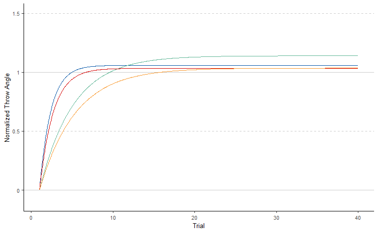

```r
fitted_data <- fitted_learning_rate_df %>%
  filter(
    experiment %in% c(
      "accel_uncued", "accel_cued_tilt",
      "rot30_uncued", "rot30_cued_tilt"
    ),
    phase == "training"
  ) %>%
  mutate(
    pert = factor(str_split_fixed(experiment, "_", 2)[, 1]),
    cue = factor(str_split_fixed(experiment, "_", 2)[, 2])
  )

p <- fitted_data %>%
  ggplot(
    aes(x = x + 1, y = y, colour = experiment)
  ) +
  theme_classic() +
  theme(
    legend.position = "none",
    text = element_text(size = text_size)
  ) +
  labs(
    x = "Trial",
    y = "Normalized Throw Angle"
  ) +
  # add horizontal lines
  geom_hline(
    yintercept = c(0, 1), linewidth = 0.4,
    colour = "#CCCCCC", linetype = "solid"
  ) +
  geom_hline(
    yintercept = c(0.5, 1.5), linewidth = 0.4,
    colour = "#CCCCCC", linetype = "dashed"
  ) +
  # set colour palette
  scale_colour_manual(values = pallete_list) +
  scale_fill_manual(values = pallete_list) + # scale axes
  scale_y_continuous(
    breaks = c(0, 0.5, 1, 1.5),
    labels = c(0, 0.5, 1, 1.5),
    limits = c(-0.1, 1.5)
  ) +
  scale_x_continuous(
    breaks = curve_x_breaks,
    labels = curve_x_breaks
  ) +
  geom_line()

# save
if (save_plots) {
  ggsave(
    p,
    filename = "../data/figs/paper_figs/fig2_initial_exps_training_fitted_only.pdf", device = "pdf",
    height = 2, width = curve_fig_width
  )
}

p
```

## 1.5 Training - Fit Learning Rates

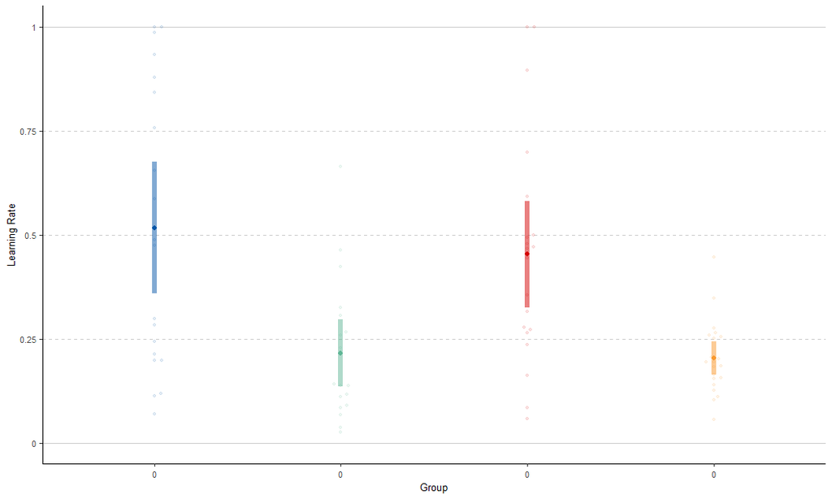

```r
data_per_ppt <- init_learning_rates %>%
  filter(
    experiment %in% c(
      "accel_uncued", "accel_cued_tilt",
      "rot30_uncued", "rot30_cued_tilt"
    ),
    phase == "training"
  ) %>%
  mutate(
    pert = factor(str_split_fixed(experiment, "_", 2)[, 1]),
    cue = factor(str_split_fixed(experiment, "_", 2)[, 2]),
    ppid = factor(ppid)
  )

data_per_group <- data_per_ppt %>%
  group_by(experiment, phase) %>%
  summarise(
    mean_learning_rate = mean(exp_fit_lambda),
    ci_learning_rate = vector_confint(exp_fit_lambda),
    mean_high = mean(exp_fit_N0),
    ci_high = vector_confint(exp_fit_N0),
    n = n(),
    .groups = "drop"
  )

p <- data_per_group %>%
  ggplot(
    aes(x = experiment, y = mean_learning_rate, colour = experiment)
  ) +
  theme_classic() +
  labs(
    x = per_group_x_labs,
    y = "Learning Rate"
  ) +
  # remove all x axis labels
  theme(
    # axis.text.x = element_blank(),
    legend.position = "none",
    # strip.text.x = element_blank(),
    text = element_text(size = text_size)
  ) +
  # colour legend settings
  guides(
    colour = guide_legend(override.aes = list(alpha = 1))
  ) +
  # set colour palette
  scale_colour_manual(values = pallete_list) +
  scale_fill_manual(
    values = pallete_list
  ) +
  # add horizontal lines
  geom_hline(
    yintercept = c(0, 1), linewidth = 0.4,
    colour = "#CCCCCC", linetype = "solid"
  ) +
  geom_hline(
    yintercept = c(0.25, 0.5, 0.75), linewidth = 0.4,
    colour = "#CCCCCC", linetype = "dashed"
  ) +
  # y-axis scale
  scale_y_continuous(
    # limits = c(-35, 5),
    breaks = c(0, 0.25, 0.5, 0.75, 1),
    labels = c(0, 0.25, 0.5, 0.75, 1)
  ) +
  scale_x_discrete(
    # limits = c(-35, 5),
    labels = c(0, 0, 0, 0)
  ) +
  # add data points
  geom_beeswarm(
    data = data_per_ppt,
    aes(
      y = exp_fit_lambda
    ),
    alpha = 0.1,
    size = 1
  ) +
  geom_linerange(aes(
    ymin = mean_learning_rate - ci_learning_rate,
    ymax = mean_learning_rate + ci_learning_rate
  ), alpha = 0.5, lwd = 2) +
  geom_point()

# save
if (save_plots) {
  ggsave(
    p,
    filename = "../data/figs/paper_figs/fig2_initial_exps_training_learning_rates.pdf", device = "pdf",
    height = 2, width = per_group_fig_width
  )
}

p
```

### 1.5.1 Statistics

We are using the afex package for the aov_car function. This allows for used mixed (within/between) factor ANOVAs. Here is an example formula for using aov_car: dependent_variable ~ between_factor1 * between_factor2 + Error(subject/(within_factor * within_factor))

```r
(temp_ANOVA <- aov_car(
  exp_fit_lambda ~ pert * cue + Error(ppid),
  data_per_ppt,
  include_aov = TRUE
))
```

```
Contrasts set to contr.sum for the following variables: pert, cue
```

```
Anova Table (Type 3 tests)

Response: exp_fit_lambda
    Effect    df  MSE         F  ges p.value
1     pert 1, 76 0.06      0.52 .007    .474
2      cue 1, 76 0.06 27.06 *** .263   <.001
3 pert:cue 1, 76 0.06      0.24 .003    .629
---
Signif. codes:  0 ‘***’ 0.001 ‘**’ 0.01 ‘*’ 0.05 ‘+’ 0.1 ‘ ’ 1
```

```r
print("Bayes anovas and bayes factors:")
```

```
[1] "Bayes anovas and bayes factors:"
```

```r
print("")
```

```
[1] ""
```

```r
bf <- anovaBF(exp_fit_lambda ~ pert * cue, data = data.frame(data_per_ppt), progress = FALSE)
print(bf)
```

```
Bayes factor analysis
--------------
[1] pert                  : 0.2947899 ±0.02%
[2] cue                   : 11137.83  ±0%
[3] pert + cue            : 3280.658  ±0.89%
[4] pert + cue + pert:cue : 1095.576  ±1.23%

Against denominator:
  Intercept only
---
Bayes factor type: BFlinearModel, JZS
```

```r
print(bayesfactor_inclusion(bf))
```

```
Inclusion Bayes Factors (Model Averaged)

         P(prior) P(posterior) Inclusion BF
pert         0.60         0.28        0.262
cue          0.60         1.00     7.99e+03
cue:pert     0.20         0.07        0.304

* Compared among: all models
*    Priors odds: uniform-equal
```

Pairwise comparisons:

```r
# posthoc tests
# (m1 <- emmeans(temp_ANOVA, ~pert))
# print("Pairwise comparisons:")
# print(summary(pairs(m1), adjust = "tukey")) # Note: default multiplicity correction for pairs summary is Tukey HSD

# Note: default multiplicity correction for pairs summary is Tukey HSD
print("----------------------------- EMMs -----------------------------")
```

```
[1] "----------------------------- EMMs -----------------------------"
```

```r
emms_obj <- emmeans(temp_ANOVA, "cue")
```

```
NOTE: Results may be misleading due to involvement in interactions
```

```r
print(pwpm(emms_obj, diffs = FALSE))
```

```
          cued_tilt  uncued
cued_tilt   [0.486]  <.0001
uncued              [0.210]

Row and column labels: cue
Upper triangle: P values
Diagonal: [Estimates] (emmean)
```

```r
# Effect size is Cohen's D
eff_size(emms_obj, edf = temp_ANOVA$anova_table$`den Df`[1], sigma = sigma(temp_ANOVA$lm))
```

```
 contrast           effect.size    SE df lower.CL upper.CL
 cued_tilt - uncued        1.16 0.243 76     0.68     1.65

Results are averaged over the levels of: pert
sigma used for effect sizes: 0.2365
Confidence level used: 0.95
```

```r
print("----------------------------- Full Tukey HSD -----------------------------")
```

```
[1] "----------------------------- Full Tukey HSD -----------------------------"
```

```r
print(TukeyHSD(temp_ANOVA$aov))
```

```
  Tukey multiple comparisons of means
    95% family-wise confidence level

Fit: aov(formula = tmp_formula, data = dat.ret, contrasts = contrasts)

$pert
                   diff        lwr        upr     p adj
rot30-accel -0.04499446 -0.1503358 0.06034689 0.3976065

$cue
                       diff        lwr        upr   p adj
uncued-cued_tilt -0.2743927 -0.3797012 -0.1690843 1.7e-06

$`pert:cue`
                                       diff        lwr         upr     p adj
rot30:cued_tilt-accel:cued_tilt -0.06375958 -0.2601800  0.13266083 0.8289773
accel:uncued-accel:cued_tilt    -0.30087254 -0.4998606 -0.10188442 0.0009089
rot30:uncued-accel:cued_tilt    -0.31330081 -0.5073688 -0.11923282 0.0003560
accel:uncued-rot30:cued_tilt    -0.23711295 -0.4361011 -0.03812484 0.0129703
rot30:uncued-rot30:cued_tilt    -0.24954123 -0.4436092 -0.05547323 0.0062253
rot30:uncued-accel:uncued       -0.01242827 -0.2090947  0.18423813 0.9983586
```

```r
print(eff_size(emmeans(temp_ANOVA$aov, c("pert", "cue")),
  edf = temp_ANOVA$anova_table$`den Df`[1],
  sigma = sigma(temp_ANOVA$lm)
))
```

```
 contrast                          effect.size    SE df lower.CL upper.CL
 accel cued_tilt - rot30 cued_tilt      0.2696 0.317 76   -0.362    0.901
 accel cued_tilt - accel uncued         1.2724 0.337 76    0.602    1.943
 accel cued_tilt - rot30 uncued         1.3250 0.330 76    0.667    1.983
 rot30 cued_tilt - accel uncued         1.0028 0.331 76    0.344    1.661
 rot30 cued_tilt - rot30 uncued         1.0553 0.324 76    0.410    1.701
 accel uncued - rot30 uncued            0.0526 0.317 76   -0.578    0.683

sigma used for effect sizes: 0.2365
Confidence level used: 0.95
```

## 1.6 Training - Fit High Points (Asymptotes)

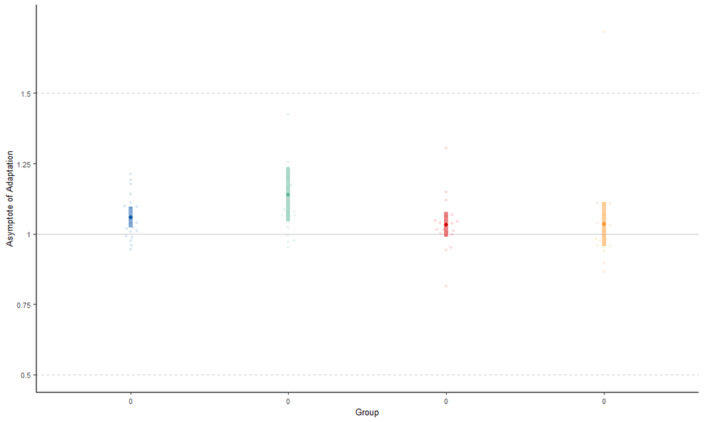

```r
p <- data_per_group %>%
  ggplot(
    aes(x = experiment, y = mean_high, colour = experiment)
  ) +
  theme_classic() +
  labs(
    x = per_group_x_labs,
    y = "Asymptote of Adaptation"
  ) +
  # for the colour legend, only show the first 7
  # Note this doesn't work for the plotly plot
  guides(
    colour = guide_legend(override.aes = list(alpha = 1))
  ) +
  # set colour palette
  scale_colour_manual(values = pallete_list) +
  scale_fill_manual(values = pallete_list) +
  # add horizontal lines
  geom_hline(
    yintercept = c(1), linewidth = 0.4,
    colour = "#CCCCCC", linetype = "solid"
  ) +
  geom_hline(
    yintercept = c(0.5, 1.5), linewidth = 0.4,
    colour = "#CCCCCC", linetype = "dashed"
  ) +
  # y-axis scale
  scale_y_continuous(
    limits = c(0.5, 1.75),
    breaks = c(0.5, 0.75, 1, 1.25, 1.5),
    labels = c(0.5, 0.75, 1, 1.25, 1.5)
  ) +
  scale_x_discrete(
    labels = c(0, 0, 0, 0)
  ) +
  # remove all x axis labels
  theme(
    legend.position = "none",
    text = element_text(size = text_size)
  ) +
  # add data points
  geom_beeswarm(
    data = data_per_ppt,
    aes(
      y = exp_fit_N0
    ),
    alpha = 0.1,
    size = 1
  ) +
  geom_linerange(aes(
    ymin = mean_high - ci_high,
    ymax = mean_high + ci_high
  ), alpha = 0.5, lwd = 2) +
  geom_point()

# save
if (save_plots) {
  ggsave(
    p,
    filename = "../data/figs/paper_figs/fig2_initial_exps_training_asymptotes.pdf", device = "pdf",
    height = 2, width = per_group_fig_width
  )
}

p
```

```r
(temp_ANOVA <- aov_car(
  exp_fit_N0 ~ pert * cue + Error(ppid),
  data_per_ppt,
  include_aov = TRUE
))
```

```
Contrasts set to contr.sum for the following variables: pert, cue
```

```
Anova Table (Type 3 tests)

Response: exp_fit_N0
    Effect    df  MSE      F  ges p.value
1     pert 1, 76 0.02 4.09 * .051    .047
2      cue 1, 76 0.02   1.66 .021    .201
3 pert:cue 1, 76 0.02   1.52 .020    .222
---
Signif. codes:  0 ‘***’ 0.001 ‘**’ 0.01 ‘*’ 0.05 ‘+’ 0.1 ‘ ’ 1
```

```r
print("Bayes anovas and bayes factors:")
```

```
[1] "Bayes anovas and bayes factors:"
```

```r
print("")
```

```
[1] ""
```

```r
bf <- anovaBF(exp_fit_N0 ~ pert * cue, data = data.frame(data_per_ppt), progress = FALSE)
print(bf)
```

```
Bayes factor analysis
--------------
[1] pert                  : 1.241972  ±0.01%
[2] cue                   : 0.4252962 ±0.01%
[3] pert + cue            : 0.5676504 ±0.86%
[4] pert + cue + pert:cue : 0.3208098 ±1.13%

Against denominator:
  Intercept only
---
Bayes factor type: BFlinearModel, JZS
```

```r
print(bayesfactor_inclusion(bf))
```

```
Inclusion Bayes Factors (Model Averaged)

         P(prior) P(posterior) Inclusion BF
pert         0.60         0.60        0.996
cue          0.60         0.37        0.391
cue:pert     0.20         0.09        0.397

* Compared among: all models
*    Priors odds: uniform-equal
```

Pairwise comparisons:

```r
# posthoc tests
# (m1 <- emmeans(temp_ANOVA, ~pert))
# print("Pairwise comparisons:")
# print(summary(pairs(m1), adjust = "tukey")) # Note: default multiplicity correction for pairs summary is Tukey HSD

# Note: default multiplicity correction for pairs summary is Tukey HSD
print("----------------------------- EMMs -----------------------------")
```

```
[1] "----------------------------- EMMs -----------------------------"
```

```r
emms_obj <- emmeans(temp_ANOVA, "pert")
```

```
NOTE: Results may be misleading due to involvement in interactions
```

```r
print(pwpm(emms_obj, diffs = FALSE))
```

```
       accel  rot30
accel [1.10] 0.0467
rot30        [1.03]

Row and column labels: pert
Upper triangle: P values
Diagonal: [Estimates] (emmean)
```

```r
# Effect size is Cohen's D
eff_size(emms_obj, edf = temp_ANOVA$anova_table$`den Df`[1], sigma = sigma(temp_ANOVA$lm))
```

```
 contrast      effect.size    SE df lower.CL upper.CL
 accel - rot30       0.452 0.227 76  0.00081    0.904

Results are averaged over the levels of: cue
sigma used for effect sizes: 0.1437
Confidence level used: 0.95
```

```r
print("----------------------------- Full Tukey HSD -----------------------------")
```

```
[1] "----------------------------- Full Tukey HSD -----------------------------"
```

```r
print(TukeyHSD(temp_ANOVA$aov))
```

```
  Tukey multiple comparisons of means
    95% family-wise confidence level

Fit: aov(formula = tmp_formula, data = dat.ret, contrasts = contrasts)

$pert
                   diff        lwr          upr    p adj
rot30-accel -0.06395532 -0.1279799 6.922626e-05 0.050242

$cue
                      diff         lwr       upr     p adj
uncued-cued_tilt 0.0404192 -0.02358534 0.1044237 0.2123325

$`pert:cue`
                                        diff         lwr        upr     p adj
rot30:cued_tilt-accel:cued_tilt -0.025412403 -0.14479315 0.09396834 0.9437626
accel:uncued-accel:cued_tilt     0.081040072 -0.03990127 0.20198142 0.3005003
rot30:uncued-accel:cued_tilt    -0.023580795 -0.14153178 0.09437019 0.9527578
accel:uncued-rot30:cued_tilt     0.106452475 -0.01448887 0.22739382 0.1042691
rot30:uncued-rot30:cued_tilt     0.001831608 -0.11611938 0.11978259 0.9999754
rot30:uncued-accel:uncued       -0.104620867 -0.22415112 0.01490938 0.1072634
```

```r
print(eff_size(emmeans(temp_ANOVA$aov, c("pert", "cue")),
  edf = temp_ANOVA$anova_table$`den Df`[1],
  sigma = sigma(temp_ANOVA$lm)
))
```

```
 contrast                          effect.size    SE df lower.CL upper.CL
 accel cued_tilt - rot30 cued_tilt      0.1768 0.317 76  -0.4536   0.8073
 accel cued_tilt - accel uncued        -0.5639 0.324 76  -1.2084   0.0806
 accel cued_tilt - rot30 uncued         0.1641 0.313 76  -0.4588   0.7869
 rot30 cued_tilt - accel uncued        -0.7407 0.326 76  -1.3899  -0.0915
 rot30 cued_tilt - rot30 uncued        -0.0127 0.312 76  -0.6350   0.6095
 accel uncued - rot30 uncued            0.7280 0.322 76   0.0865   1.3694

sigma used for effect sizes: 0.1437
Confidence level used: 0.95
```

## 1.7 Normalized Washout Phases

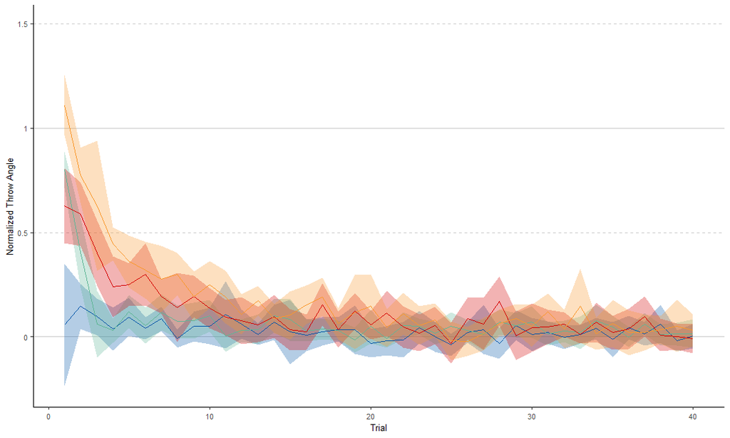

```r
# rest of the exps
data_per_group <- omnibus_df %>%
  filter(
    trial_num >= 214,
    phase == "washout",
    learning_and_decay_curves == 1
  ) %>%
  group_by(experiment, phase, trial_num) %>%
  summarise(
    mean_deviation = mean(norm_throw_deviation),
    ci_deviation = vector_confint(norm_throw_deviation),
    .groups = "drop"
  ) %>%
  arrange(experiment, trial_num)

# add a dummy column with repeating sequence
# NOTE: this can't be combined with above since we are using nrow
data_per_group <- data_per_group %>%
  mutate(dummy_x = rep(1:(nrow(data_per_group) / num_exps),
    length.out = nrow(data_per_group)
  ))

# set up plot
p <- data_per_group %>%
  ggplot(
    aes(
      x = dummy_x, y = mean_deviation, colour = experiment
    )
  ) +
  theme_classic() +
  theme(
    legend.position = "none",
    text = element_text(size = text_size)
  ) +
  labs(
    x = "Trial",
    y = "Normalized Throw Angle"
  ) +
  # add horizontal lines
  geom_hline(
    yintercept = c(0, 1), linewidth = 0.4,
    colour = "#CCCCCC", linetype = "solid"
  ) +
  geom_hline(
    yintercept = c(0.5, 1.5), linewidth = 0.4,
    colour = "#CCCCCC", linetype = "dashed"
  ) +
  # set colour palette
  scale_colour_manual(values = pallete_list) +
  scale_fill_manual(values = pallete_list) + # scale axes
  scale_y_continuous(
    breaks = c(0, 0.5, 1, 1.5),
    labels = c(0, 0.5, 1, 1.5),
    limits = c(-0.25, 1.5)
  ) +
  scale_x_continuous(
    breaks = curve_x_breaks,
    labels = curve_x_breaks
  )

# add confidence intervals and data points
for (uniq_phase in unique(data_per_group$phase)) {
  # get the data for this block
  to_plot_data <- filter(data_per_group, phase == uniq_phase)

  p <- p + geom_ribbon(
    data = to_plot_data,
    aes(
      ymin = mean_deviation - ci_deviation,
      ymax = mean_deviation + ci_deviation,
      fill = experiment
    ), colour = NA, alpha = 0.3
  ) + geom_line(
    data = to_plot_data
  )
}

# # fitted curves
# p <- p + geom_line(
#   data = filter(
#     fitted_learning_rate_df,
#     experiment %in% c(
#       "accel_uncued", "accel_cued_tilt",
#       "rot30_uncued", "rot30_cued_tilt"
#     ),
#     phase == "washout"
#   ),
#   aes(x = x + 1, y = y)
# )

# save
if (save_plots) {
  ggsave(
    p,
    filename = "../data/figs/paper_figs/fig2_initial_exps_normalized_washout.pdf", device = "pdf",
    height = 2, width = curve_fig_width
  )
}

p
```

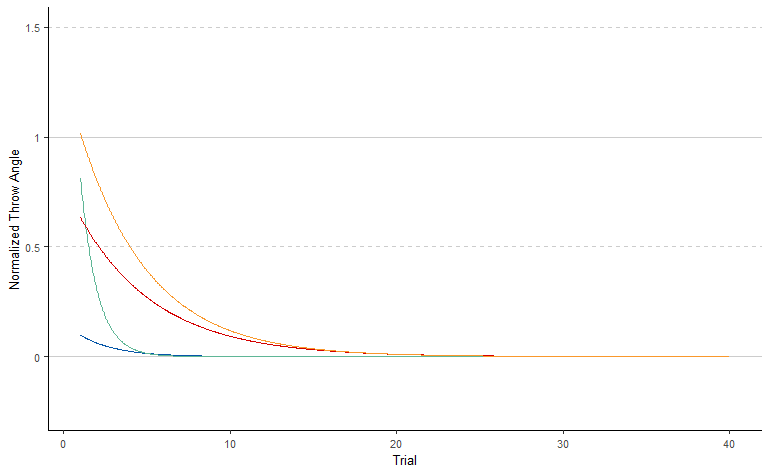

```r
fitted_data <- fitted_learning_rate_df %>%
  filter(
    experiment %in% c(
      "accel_uncued", "accel_cued_tilt",
      "rot30_uncued", "rot30_cued_tilt"
    ),
    phase == "washout"
  ) %>%
  mutate(
    pert = factor(str_split_fixed(experiment, "_", 2)[, 1]),
    cue = factor(str_split_fixed(experiment, "_", 2)[, 2])
  )

p <- fitted_data %>%
  ggplot(
    aes(x = x + 1, y = y, colour = experiment)
  ) +
  theme_classic() +
  theme(
    legend.position = "none",
    text = element_text(size = text_size)
  ) +
  labs(
    x = "Trial",
    y = "Normalized Throw Angle"
  ) +
  # add horizontal lines
  geom_hline(
    yintercept = c(0, 1), linewidth = 0.4,
    colour = "#CCCCCC", linetype = "solid"
  ) +
  geom_hline(
    yintercept = c(0.5, 1.5), linewidth = 0.4,
    colour = "#CCCCCC", linetype = "dashed"
  ) +
  # set colour palette
  scale_colour_manual(values = pallete_list) +
  scale_fill_manual(values = pallete_list) + # scale axes
  scale_y_continuous(
    breaks = c(0, 0.5, 1, 1.5),
    labels = c(0, 0.5, 1, 1.5),
    limits = c(-0.25, 1.5)
  ) +
  scale_x_continuous(
    breaks = curve_x_breaks,
    labels = curve_x_breaks
  ) +
  geom_line()

# save
if (save_plots) {
  ggsave(
    p,
    filename = "../data/figs/paper_figs/fig2_initial_exps_washout_fitted_only.pdf", device = "pdf",
    height = 2, width = curve_fig_width
  )
}

p
```

## 1.8 Washout - Fit Learning Rates

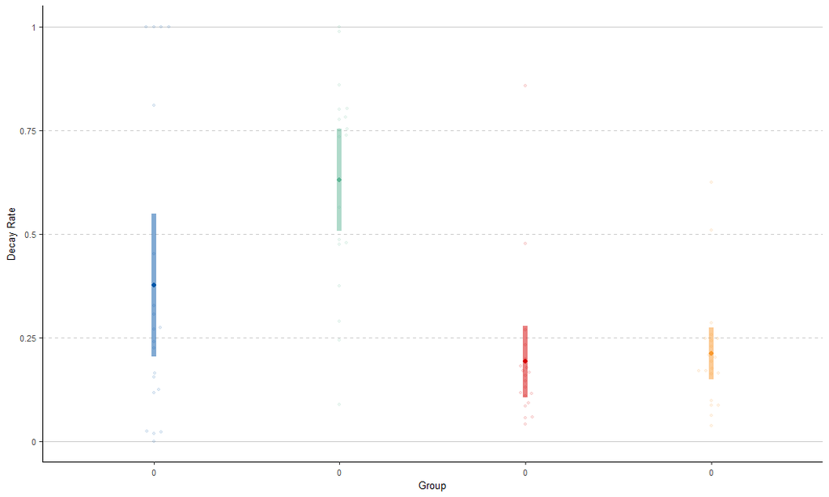

```r
data_per_ppt <- init_learning_rates %>%
  filter(
    experiment %in% c(
      "accel_uncued", "accel_cued_tilt",
      "rot30_uncued", "rot30_cued_tilt"
    ),
    phase == "washout"
  ) %>%
  mutate(
    pert = factor(str_split_fixed(experiment, "_", 2)[, 1]),
    cue = factor(str_split_fixed(experiment, "_", 2)[, 2]),
    ppid = factor(ppid)
  )

data_per_group <- data_per_ppt %>%
  group_by(experiment, phase) %>%
  summarise(
    mean_learning_rate = mean(exp_fit_lambda),
    ci_learning_rate = vector_confint(exp_fit_lambda),
    mean_high = mean(exp_fit_N0),
    ci_high = vector_confint(exp_fit_N0),
    .groups = "drop"
  )

p <- data_per_group %>%
  ggplot(
    aes(x = experiment, y = mean_learning_rate, colour = experiment)
  ) +
  theme_classic() +
  labs(
    x = per_group_x_labs,
    y = "Decay Rate"
  ) +
  # remove all x axis labels
  theme(
    legend.position = "none",
    text = element_text(size = text_size)
  ) +
  # colour legend settings
  guides(
    colour = guide_legend(override.aes = list(alpha = 1))
  ) +
  # set colour palette
  scale_colour_manual(values = pallete_list) +
  scale_fill_manual(
    values = pallete_list
  ) +
  # add horizontal lines
  geom_hline(
    yintercept = c(0, 1), linewidth = 0.4,
    colour = "#CCCCCC", linetype = "solid"
  ) +
  geom_hline(
    yintercept = c(0.25, 0.5, 0.75), linewidth = 0.4,
    colour = "#CCCCCC", linetype = "dashed"
  ) +
  # y-axis scale
  scale_y_continuous(
    # limits = c(-35, 5),
    breaks = c(0, 0.25, 0.5, 0.75, 1),
    labels = c(0, 0.25, 0.5, 0.75, 1)
  ) +
  scale_x_discrete(
    labels = c(0, 0, 0, 0)
  ) +
  # add data points
  geom_beeswarm(
    data = data_per_ppt,
    aes(
      y = exp_fit_lambda
    ),
    alpha = 0.1,
    size = 1
  ) +
  geom_linerange(aes(
    ymin = mean_learning_rate - ci_learning_rate,
    ymax = mean_learning_rate + ci_learning_rate
  ), alpha = 0.5, lwd = 2) +
  geom_point()

# save
if (save_plots) {
  ggsave(
    p,
    filename = "../data/figs/paper_figs/fig2_initial_exps_washout_learning_rates.pdf", device = "pdf",
    height = 2, width = per_group_fig_width
  )
}

p
```

```r
(temp_ANOVA <- aov_car(
  exp_fit_lambda ~ pert * cue + Error(ppid),
  data_per_ppt,
  include_aov = TRUE
))
```

```
Contrasts set to contr.sum for the following variables: pert, cue
```

```
Anova Table (Type 3 tests)

Response: exp_fit_lambda
    Effect    df  MSE         F  ges p.value
1     pert 1, 76 0.06 29.01 *** .276   <.001
2      cue 1, 76 0.06    6.03 * .074    .016
3 pert:cue 1, 76 0.06    4.39 * .055    .040
---
Signif. codes:  0 ‘***’ 0.001 ‘**’ 0.01 ‘*’ 0.05 ‘+’ 0.1 ‘ ’ 1
```

```r
print("Bayes anovas and bayes factors:")
```

```
[1] "Bayes anovas and bayes factors:"
```

```r
print("")
```

```
[1] ""
```

```r
bf <- anovaBF(exp_fit_lambda ~ pert * cue, data = data.frame(data_per_ppt), progress = FALSE)
print(bf)
```

```
Bayes factor analysis
--------------
[1] pert                  : 5668.621 ±0%
[2] cue                   : 1.128843 ±0.01%
[3] pert + cue            : 12993.34 ±1.95%
[4] pert + cue + pert:cue : 22583.27 ±1.8%

Against denominator:
  Intercept only
---
Bayes factor type: BFlinearModel, JZS
```

```r
print(bayesfactor_inclusion(bf))
```

```
Inclusion Bayes Factors (Model Averaged)

         P(prior) P(posterior) Inclusion BF
pert         0.60         1.00     1.29e+04
cue          0.60         0.86         4.18
cue:pert     0.20         0.55         4.84

* Compared among: all models
*    Priors odds: uniform-equal
```

Pairwise comparisons:

```r
# posthoc tests
# (m1 <- emmeans(temp_ANOVA, ~pert))
# print("Pairwise comparisons:")
# print(summary(pairs(m1), adjust = "tukey")) # Note: default multiplicity correction for pairs summary is Tukey HSD

# Note: default multiplicity correction for pairs summary is Tukey HSD
print("-------------------------- EMMs cue --------------------------")
```

```
[1] "-------------------------- EMMs cue --------------------------"
```

```r
emms_obj <- emmeans(temp_ANOVA, "cue")
```

```
NOTE: Results may be misleading due to involvement in interactions
```

```r
print(pwpm(emms_obj, diffs = FALSE))
```

```
          cued_tilt  uncued
cued_tilt   [0.284]  0.0163
uncued              [0.422]

Row and column labels: cue
Upper triangle: P values
Diagonal: [Estimates] (emmean)
```

```r
# Effect size is Cohen's D
eff_size(emms_obj, edf = temp_ANOVA$anova_table$`den Df`[1], sigma = sigma(temp_ANOVA$lm))
```

```
 contrast           effect.size    SE df lower.CL upper.CL
 cued_tilt - uncued       -0.55 0.228 76       -1  -0.0952

Results are averaged over the levels of: pert
sigma used for effect sizes: 0.2501
Confidence level used: 0.95
```

```r
print("-------------------------- EMMs perts --------------------------")
```

```
[1] "-------------------------- EMMs perts --------------------------"
```

```r
emms_obj <- emmeans(temp_ANOVA, "pert")
```

```
NOTE: Results may be misleading due to involvement in interactions
```

```r
print(pwpm(emms_obj, diffs = FALSE))
```

```
        accel   rot30
accel [0.504]  <.0001
rot30         [0.203]

Row and column labels: pert
Upper triangle: P values
Diagonal: [Estimates] (emmean)
```

```r
# Effect size is Cohen's D
eff_size(emms_obj, edf = temp_ANOVA$anova_table$`den Df`[1], sigma = sigma(temp_ANOVA$lm))
```

```
 contrast      effect.size    SE df lower.CL upper.CL
 accel - rot30        1.21 0.244 76    0.719     1.69

Results are averaged over the levels of: cue
sigma used for effect sizes: 0.2501
Confidence level used: 0.95
```

```r
print("----------------------------- Full Tukey HSD -----------------------------")
```

```
[1] "----------------------------- Full Tukey HSD -----------------------------"
```

```r
print(TukeyHSD(temp_ANOVA$aov))
```

```
  Tukey multiple comparisons of means
    95% family-wise confidence level

Fit: aov(formula = tmp_formula, data = dat.ret, contrasts = contrasts)

$pert
                 diff       lwr        upr p adj
rot30-accel -0.297855 -0.409268 -0.1864419 1e-06

$cue
                      diff        lwr       upr     p adj
uncued-cued_tilt 0.1344381 0.02305986 0.2458163 0.0186519

$`pert:cue`
                                       diff         lwr         upr     p adj
rot30:cued_tilt-accel:cued_tilt -0.18418534 -0.39192710  0.02355641 0.1004797
accel:uncued-accel:cued_tilt     0.25463686  0.04417941  0.46509431 0.0112835
rot30:uncued-accel:cued_tilt    -0.16391138 -0.36916512  0.04134237 0.1631505
accel:uncued-rot30:cued_tilt     0.43882220  0.22836475  0.64927965 0.0000032
rot30:uncued-rot30:cued_tilt     0.02027397 -0.18497977  0.22552771 0.9938281
rot30:uncued-accel:uncued       -0.41854824 -0.62655016 -0.21054631 0.0000068
```

```r
print(eff_size(emmeans(temp_ANOVA$aov, c("pert", "cue")),
  edf = temp_ANOVA$anova_table$`den Df`[1],
  sigma = sigma(temp_ANOVA$lm)
))
```

```
 contrast                          effect.size    SE df lower.CL upper.CL
 accel cued_tilt - rot30 cued_tilt      0.7365 0.322 76   0.0955    1.377
 accel cued_tilt - accel uncued        -1.0182 0.331 76  -1.6771   -0.359
 accel cued_tilt - rot30 uncued         0.6554 0.317 76   0.0242    1.287
 rot30 cued_tilt - accel uncued        -1.7547 0.351 76  -2.4528   -1.056
 rot30 cued_tilt - rot30 uncued        -0.0811 0.313 76  -0.7035    0.541
 accel uncued - rot30 uncued            1.6736 0.344 76   0.9875    2.360

sigma used for effect sizes: 0.2501
Confidence level used: 0.95
```

## 1.9 Washout - Fit High Points (Starts)

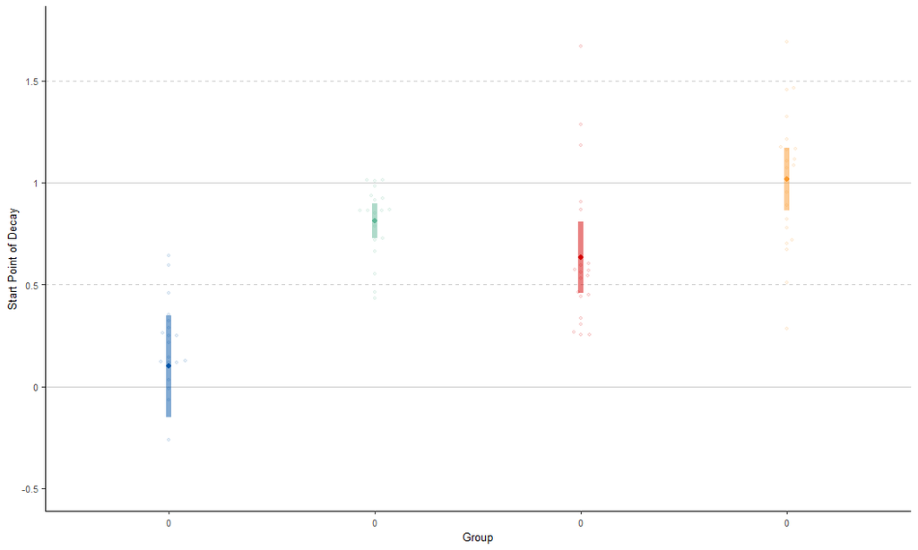

```r
p <- data_per_group %>%
  ggplot(
    aes(x = experiment, y = mean_high, colour = experiment)
  ) +
  theme_classic() +
  labs(
    x = per_group_x_labs,
    y = "Start Point of Decay"
  ) +
  # for the colour legend, only show the first 7
  # Note this doesn't work for the plotly plot
  guides(
    colour = guide_legend(override.aes = list(alpha = 1))
  ) +
  # set colour palette
  scale_colour_manual(values = pallete_list) +
  scale_fill_manual(values = pallete_list) +
  # add horizontal lines
  geom_hline(
    yintercept = c(0, 1), linewidth = 0.4,
    colour = "#CCCCCC", linetype = "solid"
  ) +
  geom_hline(
    yintercept = c(0.5, 1.5), linewidth = 0.4,
    colour = "#CCCCCC", linetype = "dashed"
  ) +
  # y-axis scale
  scale_y_continuous(
    limits = c(-0.5, 1.75),
    breaks = c(-0.5, 0, 0.5, 1, 1.5),
    labels = c(-0.5, 0, 0.5, 1, 1.5)
  ) +
  scale_x_discrete(
    labels = c(0, 0, 0, 0)
  ) +
  # remove all x axis labels
  theme(
    legend.position = "none",
    text = element_text(size = text_size)
  ) +
  # add data points
  geom_beeswarm(
    data = data_per_ppt,
    aes(
      y = exp_fit_N0
    ),
    alpha = 0.1,
    size = 1
  ) +
  geom_linerange(aes(
    ymin = mean_high - ci_high,
    ymax = mean_high + ci_high
  ), alpha = 0.5, lwd = 2) +
  geom_point()

# save
if (save_plots) {
  ggsave(
    p,
    filename = "../data/figs/paper_figs/fig2_initial_exps_washout_starts.pdf", device = "pdf",
    height = 2, width = per_group_fig_width
  )
}

p
```

Note: the outlier is ~ -2 in the Cued Accellerated group.

```r
(temp_ANOVA <- aov_car(
  exp_fit_N0 ~ pert * cue + Error(ppid),
  data_per_ppt,
  include_aov = TRUE
))
```

```
Contrasts set to contr.sum for the following variables: pert, cue
```

```
Anova Table (Type 3 tests)

Response: exp_fit_N0
    Effect    df  MSE         F  ges p.value
1     pert 1, 76 0.14 18.92 *** .199   <.001
2      cue 1, 76 0.14 41.80 *** .355   <.001
3 pert:cue 1, 76 0.14    3.76 + .047    .056
---
Signif. codes:  0 ‘***’ 0.001 ‘**’ 0.01 ‘*’ 0.05 ‘+’ 0.1 ‘ ’ 1
```

```r
print("Bayes anovas and bayes factors:")
```

```
[1] "Bayes anovas and bayes factors:"
```

```r
print("")
```

```
[1] ""
```

```r
bf <- anovaBF(exp_fit_N0 ~ pert * cue, data = data.frame(data_per_ppt), progress = FALSE)
print(bf)
```

```
Bayes factor analysis
--------------
[1] pert                  : 53.66995 ±0%
[2] cue                   : 87987.31 ±0%
[3] pert + cue            : 32059532 ±2.29%
[4] pert + cue + pert:cue : 43552554 ±1%

Against denominator:
  Intercept only
---
Bayes factor type: BFlinearModel, JZS
```

```r
print(bayesfactor_inclusion(bf))
```

```
Inclusion Bayes Factors (Model Averaged)

         P(prior) P(posterior) Inclusion BF
pert         0.60         1.00       572.90
cue          0.60         1.00     9.23e+05
cue:pert     0.20         0.58         5.42

* Compared among: all models
*    Priors odds: uniform-equal
```

Pairwise comparisons:

```r
# posthoc tests
# (m1 <- emmeans(temp_ANOVA, ~pert))
# print("Pairwise comparisons:")
# print(summary(pairs(m1), adjust = "tukey")) # Note: default multiplicity correction for pairs summary is Tukey HSD

# Note: default multiplicity correction for pairs summary is Tukey HSD
print("-------------------------- EMMs cue --------------------------")
```

```
[1] "-------------------------- EMMs cue --------------------------"
```

```r
emms_obj <- emmeans(temp_ANOVA, "cue")
```

```
NOTE: Results may be misleading due to involvement in interactions
```

```r
print(pwpm(emms_obj, diffs = FALSE))
```

```
          cued_tilt  uncued
cued_tilt   [0.365]  <.0001
uncued              [0.914]

Row and column labels: cue
Upper triangle: P values
Diagonal: [Estimates] (emmean)
```

```r
# Effect size is Cohen's D
eff_size(emms_obj, edf = temp_ANOVA$anova_table$`den Df`[1], sigma = sigma(temp_ANOVA$lm))
```

```
 contrast           effect.size    SE df lower.CL upper.CL
 cued_tilt - uncued       -1.45 0.253 76    -1.95   -0.943

Results are averaged over the levels of: pert
sigma used for effect sizes: 0.3795
Confidence level used: 0.95
```

```r
print("-------------------------- EMMs perts --------------------------")
```

```
[1] "-------------------------- EMMs perts --------------------------"
```

```r
emms_obj <- emmeans(temp_ANOVA, "pert")
```

```
NOTE: Results may be misleading due to involvement in interactions
```

```r
print(pwpm(emms_obj, diffs = FALSE))
```

```
        accel   rot30
accel [0.455]  <.0001
rot30         [0.825]

Row and column labels: pert
Upper triangle: P values
Diagonal: [Estimates] (emmean)
```

```r
# Effect size is Cohen's D
eff_size(emms_obj, edf = temp_ANOVA$anova_table$`den Df`[1], sigma = sigma(temp_ANOVA$lm))
```

```
 contrast      effect.size    SE df lower.CL upper.CL
 accel - rot30      -0.973 0.237 76    -1.45   -0.501

Results are averaged over the levels of: cue
sigma used for effect sizes: 0.3795
Confidence level used: 0.95
```

```r
print("----------------------------- Full Tukey HSD -----------------------------")
```

```
[1] "----------------------------- Full Tukey HSD -----------------------------"
```

```r
print(TukeyHSD(temp_ANOVA$aov))
```

```
  Tukey multiple comparisons of means
    95% family-wise confidence level

Fit: aov(formula = tmp_formula, data = dat.ret, contrasts = contrasts)

$pert
                 diff       lwr       upr    p adj
rot30-accel 0.3832283 0.2141604 0.5522961 2.28e-05

$cue
                      diff       lwr       upr p adj
uncued-cued_tilt 0.5445602 0.3755452 0.7135752     0

$`pert:cue`
                                     diff         lwr       upr     p adj
rot30:cued_tilt-accel:cued_tilt 0.5341088  0.21886341 0.8493542 0.0001671
accel:uncued-accel:cued_tilt    0.7137418  0.39437533 1.0331082 0.0000006
rot30:uncued-accel:cued_tilt    0.9184151  0.60694526 1.2298850 0.0000000
accel:uncued-rot30:cued_tilt    0.1796329 -0.13973350 0.4989994 0.4560098
rot30:uncued-rot30:cued_tilt    0.3843063  0.07283643 0.6957762 0.0093833
rot30:uncued-accel:uncued       0.2046734 -0.11096684 0.5203136 0.3291174
```

```r
print(eff_size(emmeans(temp_ANOVA$aov, c("pert", "cue")),
  edf = temp_ANOVA$anova_table$`den Df`[1],
  sigma = sigma(temp_ANOVA$lm)
))
```

```
 contrast                          effect.size    SE df lower.CL upper.CL
 accel cued_tilt - rot30 cued_tilt      -1.407 0.336 76    -2.08  -0.7378
 accel cued_tilt - accel uncued         -1.881 0.355 76    -2.59  -1.1740
 accel cued_tilt - rot30 uncued         -2.420 0.369 76    -3.15  -1.6851
 rot30 cued_tilt - accel uncued         -0.473 0.323 76    -1.12   0.1693
 rot30 cued_tilt - rot30 uncued         -1.013 0.323 76    -1.66  -0.3692
 accel uncued - rot30 uncued            -0.539 0.320 76    -1.18   0.0973

sigma used for effect sizes: 0.3795
Confidence level used: 0.95
```

# 2 Alternate Washout Phases

These include the last trial of the Training phase for all Cued conditions.

## 2.1 Normalized Washout Phases

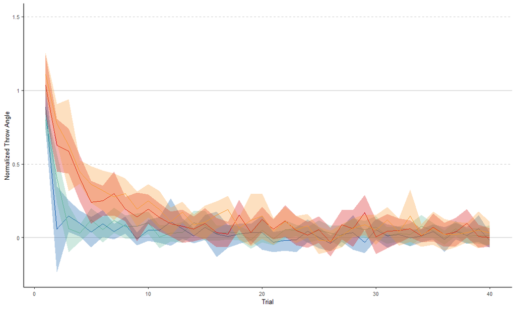

```r
# rest of the exps
data_per_group <- omnibus_df %>%
  filter(
    trial_num >= 214,
    alt_washout_block == TRUE,
  ) %>%
  arrange(experiment, ppid, trial_num) %>%
  group_by(experiment, trial_num) %>%
  summarise(
    mean_deviation = mean(norm_throw_deviation),
    ci_deviation = vector_confint(norm_throw_deviation),
    .groups = "drop"
  )

# NOTE: this can't be combined with above since we are using nrow
data_per_group <- data_per_group %>%
  mutate(dummy_x = rep(1:40,
    length.out = nrow(data_per_group)
  ))

# add a dummy column with repeating sequence


# set up plot
p <- data_per_group %>%
  ggplot(
    aes(
      x = dummy_x, y = mean_deviation, colour = experiment
    )
  ) +
  theme_classic() +
  theme(
    legend.position = "none",
    text = element_text(size = text_size)
  ) +
  labs(
    x = "Trial",
    y = "Normalized Throw Angle"
  ) +
  # add horizontal lines
  geom_hline(
    yintercept = c(0, 1), linewidth = 0.4,
    colour = "#CCCCCC", linetype = "solid"
  ) +
  geom_hline(
    yintercept = c(0.5, 1.5), linewidth = 0.4,
    colour = "#CCCCCC", linetype = "dashed"
  ) +
  # set colour palette
  scale_colour_manual(values = pallete_list) +
  scale_fill_manual(values = pallete_list) + # scale axes
  scale_y_continuous(
    breaks = c(0, 0.5, 1, 1.5),
    labels = c(0, 0.5, 1, 1.5),
    limits = c(-0.25, 1.5)
  ) +
  scale_x_continuous(
    breaks = curve_x_breaks,
    labels = curve_x_breaks
  )

# add confidence intervals and data points
for (uniq_exp in unique(data_per_group$experiment)) {
  # get the data for this block
  to_plot_data <- filter(data_per_group, experiment == uniq_exp)

  p <- p + geom_ribbon(
    data = to_plot_data,
    aes(
      ymin = mean_deviation - ci_deviation,
      ymax = mean_deviation + ci_deviation,
      fill = experiment
    ), colour = NA, alpha = 0.3
  ) + geom_line(
    data = to_plot_data
  )
}

# save
if (save_plots) {
  ggsave(
    p,
    filename = "../data/figs/paper_figs/fig2_initial_exps_alt_washout.pdf", device = "pdf",
    height = 2, width = curve_fig_width
  )
}

p
```

```r
# ggplotly(p)
```

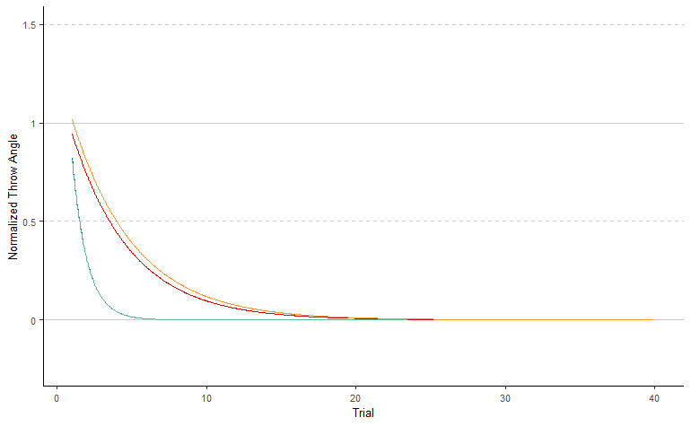

```r
fitted_data <- fitted_alt_washout_df %>%
  filter(
    experiment %in% c(
      "accel_uncued", "accel_cued_tilt",
      "rot30_uncued", "rot30_cued_tilt"
    ),
    phase == "washout"
  ) %>%
  mutate(
    pert = factor(str_split_fixed(experiment, "_", 2)[, 1]),
    cue = factor(str_split_fixed(experiment, "_", 2)[, 2])
  )

p <- fitted_data %>%
  ggplot(
    aes(x = x + 1, y = y, colour = experiment)
  ) +
  theme_classic() +
  theme(
    legend.position = "none",
    text = element_text(size = text_size)
  ) +
  labs(
    x = "Trial",
    y = "Normalized Throw Angle"
  ) +
  # add horizontal lines
  geom_hline(
    yintercept = c(0, 1), linewidth = 0.4,
    colour = "#CCCCCC", linetype = "solid"
  ) +
  geom_hline(
    yintercept = c(0.5, 1.5), linewidth = 0.4,
    colour = "#CCCCCC", linetype = "dashed"
  ) +
  # set colour palette
  scale_colour_manual(values = pallete_list) +
  scale_fill_manual(values = pallete_list) + # scale axes
  scale_y_continuous(
    breaks = c(0, 0.5, 1, 1.5),
    labels = c(0, 0.5, 1, 1.5),
    limits = c(-0.25, 1.5)
  ) +
  scale_x_continuous(
    breaks = curve_x_breaks,
    labels = curve_x_breaks
  ) +
  geom_line()

# save
if (save_plots) {
  ggsave(
    p,
    filename = "../data/figs/paper_figs/fig2_initial_exps_alt_washout_fitted_only.pdf", device = "pdf",
    height = 2, width = curve_fig_width
  )
}

p
```

## 2.2 Washout - Fit Learning Rates

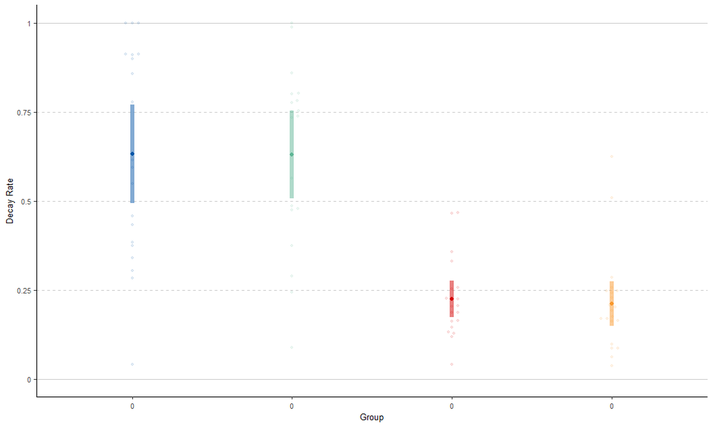

```r
data_per_ppt <- alt_washout_rates %>%
  filter(
    experiment %in% c(
      "accel_uncued", "accel_cued_tilt",
      "rot30_uncued", "rot30_cued_tilt"
    )
  ) %>%
  mutate(
    pert = factor(str_split_fixed(experiment, "_", 2)[, 1]),
    cue = factor(str_split_fixed(experiment, "_", 2)[, 2]),
    ppid = factor(ppid)
  )

data_per_group <- data_per_ppt %>%
  group_by(experiment) %>%
  summarise(
    mean_learning_rate = mean(exp_fit_lambda),
    ci_learning_rate = vector_confint(exp_fit_lambda),
    mean_high = mean(exp_fit_N0),
    ci_high = vector_confint(exp_fit_N0),
    .groups = "drop"
  )

p <- data_per_group %>%
  ggplot(
    aes(x = experiment, y = mean_learning_rate, colour = experiment)
  ) +
  theme_classic() +
  labs(
    x = per_group_x_labs,
    y = "Decay Rate"
  ) +
  # remove all x axis labels
  theme(
    legend.position = "none",
    text = element_text(size = text_size)
  ) +
  # colour legend settings
  guides(
    colour = guide_legend(override.aes = list(alpha = 1))
  ) +
  # set colour palette
  scale_colour_manual(values = pallete_list) +
  scale_fill_manual(
    values = pallete_list
  ) +
  # add horizontal lines
  geom_hline(
    yintercept = c(0, 1), linewidth = 0.4,
    colour = "#CCCCCC", linetype = "solid"
  ) +
  geom_hline(
    yintercept = c(0.25, 0.5, 0.75), linewidth = 0.4,
    colour = "#CCCCCC", linetype = "dashed"
  ) +
  # y-axis scale
  scale_y_continuous(
    # limits = c(-35, 5),
    breaks = c(0, 0.25, 0.5, 0.75, 1),
    labels = c(0, 0.25, 0.5, 0.75, 1)
  ) +
  scale_x_discrete(
    labels = c(0, 0, 0, 0)
  ) +
  # add data points
  geom_beeswarm(
    data = data_per_ppt,
    aes(
      y = exp_fit_lambda
    ),
    alpha = 0.1,
    size = 1
  ) +
  geom_linerange(aes(
    ymin = mean_learning_rate - ci_learning_rate,
    ymax = mean_learning_rate + ci_learning_rate
  ), alpha = 0.5, lwd = 2) +
  geom_point()

# save
if (save_plots) {
  ggsave(
    p,
    filename = "../data/figs/paper_figs/fig2_initial_exps_alt_washout_learning_rates.pdf", device = "pdf",
    height = 2, width = per_group_fig_width
  )
}

p
```

```r
(temp_ANOVA <- aov_car(
  exp_fit_lambda ~ pert * cue + Error(ppid),
  data_per_ppt,
  include_aov = TRUE
))
```

```
Contrasts set to contr.sum for the following variables: pert, cue
```

```
Anova Table (Type 3 tests)

Response: exp_fit_lambda
    Effect    df  MSE         F   ges p.value
1     pert 1, 76 0.05 75.59 ***  .499   <.001
2      cue 1, 76 0.05      0.02 <.001    .889
3 pert:cue 1, 76 0.05      0.01 <.001    .913
---
Signif. codes:  0 ‘***’ 0.001 ‘**’ 0.01 ‘*’ 0.05 ‘+’ 0.1 ‘ ’ 1
```

```r
print("Bayes anovas and bayes factors:")
```

```
[1] "Bayes anovas and bayes factors:"
```

```r
print("")
```

```
[1] ""
```

```r
bf <- anovaBF(exp_fit_lambda ~ pert * cue, data = data.frame(data_per_ppt), progress = FALSE)
print(bf)
```

```
Bayes factor analysis
--------------
[1] pert                  : 21342321476 ±0%
[2] cue                   : 0.2391843   ±0.02%
[3] pert + cue            : 4760781163  ±1.24%
[4] pert + cue + pert:cue : 1553175873  ±1.58%

Against denominator:
  Intercept only
---
Bayes factor type: BFlinearModel, JZS
```

```r
print(bayesfactor_inclusion(bf))
```

```
Inclusion Bayes Factors (Model Averaged)

         P(prior) P(posterior) Inclusion BF
pert         0.60         1.00     1.49e+10
cue          0.60         0.23        0.197
cue:pert     0.20         0.06        0.238

* Compared among: all models
*    Priors odds: uniform-equal
```

Pairwise comparisons:

```r
# posthoc tests
# (m1 <- emmeans(temp_ANOVA, ~pert))
# print("Pairwise comparisons:")
# print(summary(pairs(m1), adjust = "tukey")) # Note: default multiplicity correction for pairs summary is Tukey HSD

# Note: default multiplicity correction for pairs summary is Tukey HSD
print("-------------------------- EMMs cue --------------------------")
```

```
[1] "-------------------------- EMMs cue --------------------------"
```

```r
emms_obj <- emmeans(temp_ANOVA, "cue")
```

```
NOTE: Results may be misleading due to involvement in interactions
```

```r
print(pwpm(emms_obj, diffs = FALSE))
```

```
          cued_tilt  uncued
cued_tilt   [0.429]  0.8891
uncued              [0.422]

Row and column labels: cue
Upper triangle: P values
Diagonal: [Estimates] (emmean)
```

```r
# Effect size is Cohen's D
eff_size(emms_obj, edf = temp_ANOVA$anova_table$`den Df`[1], sigma = sigma(temp_ANOVA$lm))
```

```
 contrast           effect.size    SE df lower.CL upper.CL
 cued_tilt - uncued      0.0313 0.224 76   -0.414    0.477

Results are averaged over the levels of: pert
sigma used for effect sizes: 0.2125
Confidence level used: 0.95
```

```r
print("-------------------------- EMMs perts --------------------------")
```

```
[1] "-------------------------- EMMs perts --------------------------"
```

```r
emms_obj <- emmeans(temp_ANOVA, "pert")
```

```
NOTE: Results may be misleading due to involvement in interactions
```

```r
print(pwpm(emms_obj, diffs = FALSE))
```

```
        accel   rot30
accel [0.632]  <.0001
rot30         [0.219]

Row and column labels: pert
Upper triangle: P values
Diagonal: [Estimates] (emmean)
```

```r
# Effect size is Cohen's D
eff_size(emms_obj, edf = temp_ANOVA$anova_table$`den Df`[1], sigma = sigma(temp_ANOVA$lm))
```

```
 contrast      effect.size    SE df lower.CL upper.CL
 accel - rot30        1.95 0.274 76      1.4     2.49

Results are averaged over the levels of: cue
sigma used for effect sizes: 0.2125
Confidence level used: 0.95
```

```r
print("----------------------------- Full Tukey HSD -----------------------------")
```

```
[1] "----------------------------- Full Tukey HSD -----------------------------"
```

```r
print(TukeyHSD(temp_ANOVA$aov))
```

```
  Tukey multiple comparisons of means
    95% family-wise confidence level

Fit: aov(formula = tmp_formula, data = dat.ret, contrasts = contrasts)

$pert
                  diff        lwr        upr p adj
rot30-accel -0.4134892 -0.5081416 -0.3188367     0

$cue
                         diff        lwr        upr    p adj
uncued-cued_tilt -0.006780523 -0.1014034 0.08784235 0.886889

$`pert:cue`
                                        diff        lwr        upr     p adj
rot30:cued_tilt-accel:cued_tilt -0.408103702 -0.5845935 -0.2316139 0.0000003
accel:uncued-accel:cued_tilt    -0.001431779 -0.1802287  0.1773652 0.9999966
rot30:uncued-accel:cued_tilt    -0.419980015 -0.5943561 -0.2456039 0.0000001
accel:uncued-rot30:cued_tilt     0.406671923  0.2278750  0.5854689 0.0000004
rot30:uncued-rot30:cued_tilt    -0.011876312 -0.1862524  0.1624998 0.9979488
rot30:uncued-accel:uncued       -0.418548235 -0.5952591 -0.2418374 0.0000001
```

```r
print(eff_size(emmeans(temp_ANOVA$aov, c("pert", "cue")),
  edf = temp_ANOVA$anova_table$`den Df`[1],
  sigma = sigma(temp_ANOVA$lm)
))
```

```
 contrast                          effect.size    SE df lower.CL upper.CL
 accel cued_tilt - rot30 cued_tilt     1.92078 0.353 76    1.219    2.623
 accel cued_tilt - accel uncued        0.00674 0.320 76   -0.631    0.645
 accel cued_tilt - rot30 uncued        1.97668 0.351 76    1.277    2.676
 rot30 cued_tilt - accel uncued       -1.91404 0.356 76   -2.623   -1.205
 rot30 cued_tilt - rot30 uncued        0.05590 0.312 76   -0.566    0.678
 accel uncued - rot30 uncued           1.96994 0.355 76    1.264    2.676

sigma used for effect sizes: 0.2125
Confidence level used: 0.95
```

## 2.3 Washout - Fit High Points (Starts)

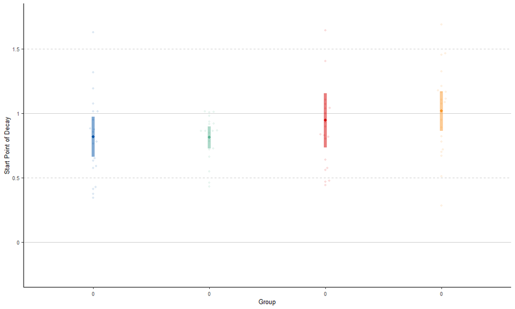

```r
p <- data_per_group %>%
  ggplot(
    aes(x = experiment, y = mean_high, colour = experiment)
  ) +
  theme_classic() +
  labs(
    x = per_group_x_labs,
    y = "Start Point of Decay"
  ) +
  # for the colour legend, only show the first 7
  # Note this doesn't work for the plotly plot
  guides(
    colour = guide_legend(override.aes = list(alpha = 1))
  ) +
  # set colour palette
  scale_colour_manual(values = pallete_list) +
  scale_fill_manual(values = pallete_list) +
  # add horizontal lines
  geom_hline(
    yintercept = c(0, 1), linewidth = 0.4,
    colour = "#CCCCCC", linetype = "solid"
  ) +
  geom_hline(
    yintercept = c(0.5, 1.5), linewidth = 0.4,
    colour = "#CCCCCC", linetype = "dashed"
  ) +
  # y-axis scale
  scale_y_continuous(
    limits = c(-0.25, 1.75),
    breaks = c(-0.5, 0, 0.5, 1, 1.5),
    labels = c(-0.5, 0, 0.5, 1, 1.5)
  ) +
  scale_x_discrete(
    labels = c(0, 0, 0, 0)
  ) +
  # remove all x axis labels
  theme(
    legend.position = "none",
    text = element_text(size = text_size)
  ) +
  # add data points
  geom_beeswarm(
    data = data_per_ppt,
    aes(
      y = exp_fit_N0
    ),
    alpha = 0.1,
    size = 1
  ) +
  geom_linerange(aes(
    ymin = mean_high - ci_high,
    ymax = mean_high + ci_high
  ), alpha = 0.5, lwd = 2) +
  geom_point()

# save
if (save_plots) {
  ggsave(
    p,
    filename = "../data/figs/paper_figs/fig2_initial_exps_alt_washout_starts.pdf", device = "pdf",
    height = 2, width = per_group_fig_width
  )
}

p
```

```r
(temp_ANOVA <- aov_car(
  exp_fit_N0 ~ pert * cue + Error(ppid),
  data_per_ppt,
  include_aov = TRUE
))
```

```
Contrasts set to contr.sum for the following variables: pert, cue
```

```
Anova Table (Type 3 tests)

Response: exp_fit_N0
    Effect    df  MSE      F  ges p.value
1     pert 1, 76 0.12 4.76 * .059    .032
2      cue 1, 76 0.12   0.19 .002    .666
3 pert:cue 1, 76 0.12   0.26 .003    .611
---
Signif. codes:  0 ‘***’ 0.001 ‘**’ 0.01 ‘*’ 0.05 ‘+’ 0.1 ‘ ’ 1
```

```r
print("Bayes anovas and bayes factors:")
```

```
[1] "Bayes anovas and bayes factors:"
```

```r
print("")
```

```
[1] ""
```

```r
bf <- anovaBF(exp_fit_N0 ~ pert * cue, data = data.frame(data_per_ppt), progress = FALSE)
print(bf)
```

```
Bayes factor analysis
--------------
[1] pert                  : 1.892857  ±0.01%
[2] cue                   : 0.258055  ±0.02%
[3] pert + cue            : 0.4742953 ±1.85%
[4] pert + cue + pert:cue : 0.1634759 ±1.25%

Against denominator:
  Intercept only
---
Bayes factor type: BFlinearModel, JZS
```

```r
print(bayesfactor_inclusion(bf))
```

```
Inclusion Bayes Factors (Model Averaged)

         P(prior) P(posterior) Inclusion BF
pert         0.60         0.67         1.34
cue          0.60         0.24        0.206
cue:pert     0.20         0.04        0.180

* Compared among: all models
*    Priors odds: uniform-equal
```

Pairwise comparisons:

```r
# posthoc tests
# (m1 <- emmeans(temp_ANOVA, ~pert))
# print("Pairwise comparisons:")
# print(summary(pairs(m1), adjust = "tukey")) # Note: default multiplicity correction for pairs summary is Tukey HSD

# Note: default multiplicity correction for pairs summary is Tukey HSD
print("-------------------------- EMMs cue --------------------------")
```

```
[1] "-------------------------- EMMs cue --------------------------"
```

```r
emms_obj <- emmeans(temp_ANOVA, "cue")
```

```
NOTE: Results may be misleading due to involvement in interactions
```

```r
print(pwpm(emms_obj, diffs = FALSE))
```

```
          cued_tilt  uncued
cued_tilt   [0.882]  0.6662
uncued              [0.914]

Row and column labels: cue
Upper triangle: P values
Diagonal: [Estimates] (emmean)
```

```r
# Effect size is Cohen's D
eff_size(emms_obj, edf = temp_ANOVA$anova_table$`den Df`[1], sigma = sigma(temp_ANOVA$lm))
```

```
 contrast           effect.size    SE df lower.CL upper.CL
 cued_tilt - uncued     -0.0969 0.224 76   -0.543    0.349

Results are averaged over the levels of: pert
sigma used for effect sizes: 0.3398
Confidence level used: 0.95
```

```r
print("-------------------------- EMMs perts --------------------------")
```

```
[1] "-------------------------- EMMs perts --------------------------"
```

```r
emms_obj <- emmeans(temp_ANOVA, "pert")
```

```
NOTE: Results may be misleading due to involvement in interactions
```

```r
print(pwpm(emms_obj, diffs = FALSE))
```

```
        accel   rot30
accel [0.815]  0.0323
rot30         [0.981]

Row and column labels: pert
Upper triangle: P values
Diagonal: [Estimates] (emmean)
```

```r
# Effect size is Cohen's D
eff_size(emms_obj, edf = temp_ANOVA$anova_table$`den Df`[1], sigma = sigma(temp_ANOVA$lm))
```

```
 contrast      effect.size    SE df lower.CL upper.CL
 accel - rot30      -0.488 0.227 76   -0.941  -0.0355

Results are averaged over the levels of: cue
sigma used for effect sizes: 0.3398
Confidence level used: 0.95
```

```r
print("----------------------------- Full Tukey HSD -----------------------------")
```

```
[1] "----------------------------- Full Tukey HSD -----------------------------"
```

```r
print(TukeyHSD(temp_ANOVA$aov))
```

```
  Tukey multiple comparisons of means
    95% family-wise confidence level

Fit: aov(formula = tmp_formula, data = dat.ret, contrasts = contrasts)

$pert
                 diff        lwr       upr     p adj
rot30-accel 0.1666051 0.01524845 0.3179617 0.0314171

$cue
                       diff       lwr       upr     p adj
uncued-cued_tilt 0.03386736 -0.117442 0.1851767 0.6570139

$`pert:cue`
                                        diff         lwr       upr     p adj
rot30:cued_tilt-accel:cued_tilt  0.126938566 -0.15528234 0.4091595 0.6403195
accel:uncued-accel:cued_tilt    -0.005951748 -0.29186197 0.2799585 0.9999408
rot30:uncued-accel:cued_tilt     0.198721623 -0.08011927 0.4775625 0.2486928
accel:uncued-rot30:cued_tilt    -0.132890314 -0.41880054 0.1530199 0.6156012
rot30:uncued-rot30:cued_tilt     0.071783057 -0.20705783 0.3506239 0.9057899
rot30:uncued-accel:uncued        0.204673371 -0.07790097 0.4872477 0.2356056
```

```r
print(eff_size(emmeans(temp_ANOVA$aov, c("pert", "cue")),
  edf = temp_ANOVA$anova_table$`den Df`[1],
  sigma = sigma(temp_ANOVA$lm)
))
```

```
 contrast                          effect.size    SE df lower.CL upper.CL
 accel cued_tilt - rot30 cued_tilt     -0.3736 0.318 76   -1.006   0.2591
 accel cued_tilt - accel uncued         0.0175 0.320 76   -0.621   0.6556
 accel cued_tilt - rot30 uncued        -0.5849 0.316 76   -1.214   0.0445
 rot30 cued_tilt - accel uncued         0.3911 0.322 76   -0.250   1.0323
 rot30 cued_tilt - rot30 uncued        -0.2113 0.313 76   -0.834   0.4119
 accel uncued - rot30 uncued           -0.6024 0.320 76   -1.240   0.0357

sigma used for effect sizes: 0.3398
Confidence level used: 0.95
```

# 3 All-Group-Alternate Washout Phases

These include the last trial of the Training phase for all conditions.

## 3.1 Normalized Washout Phases

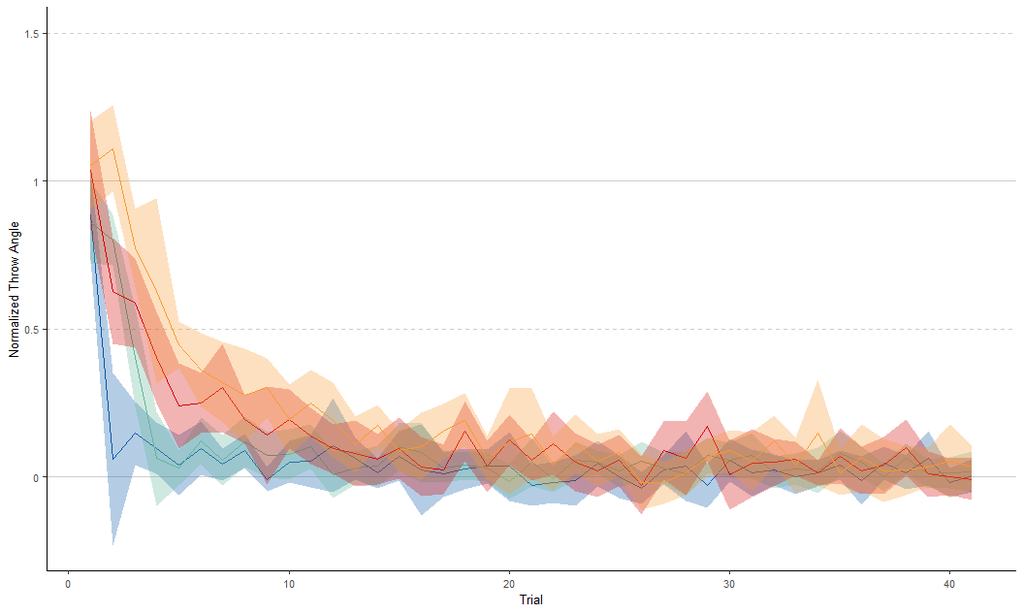

```r
# rest of the exps
data_per_group <- omnibus_df %>%
  filter(
    trial_num >= 214,
    alt_all_washout_block == TRUE,
  ) %>%
  arrange(experiment, ppid, trial_num) %>%
  group_by(experiment, trial_num) %>%
  summarise(
    mean_deviation = mean(norm_throw_deviation),
    ci_deviation = vector_confint(norm_throw_deviation),
    .groups = "drop"
  )

# NOTE: this can't be combined with above since we are using nrow
data_per_group <- data_per_group %>%
  mutate(dummy_x = rep(1:41,
    length.out = nrow(data_per_group)
  ))

# add a dummy column with repeating sequence


# set up plot
p <- data_per_group %>%
  ggplot(
    aes(
      x = dummy_x, y = mean_deviation, colour = experiment
    )
  ) +
  theme_classic() +
  theme(
    legend.position = "none",
    text = element_text(size = text_size)
  ) +
  labs(
    x = "Trial",
    y = "Normalized Throw Angle"
  ) +
  # add horizontal lines
  geom_hline(
    yintercept = c(0, 1), linewidth = 0.4,
    colour = "#CCCCCC", linetype = "solid"
  ) +
  geom_hline(
    yintercept = c(0.5, 1.5), linewidth = 0.4,
    colour = "#CCCCCC", linetype = "dashed"
  ) +
  # set colour palette
  scale_colour_manual(values = pallete_list) +
  scale_fill_manual(values = pallete_list) + # scale axes
  scale_y_continuous(
    breaks = c(0, 0.5, 1, 1.5),
    labels = c(0, 0.5, 1, 1.5)
  ) +
  scale_x_continuous(
    breaks = curve_x_breaks,
    labels = curve_x_breaks
  )

# add confidence intervals and data points
for (uniq_exp in unique(data_per_group$experiment)) {
  # get the data for this block
  to_plot_data <- filter(data_per_group, experiment == uniq_exp)

  p <- p + geom_ribbon(
    data = to_plot_data,
    aes(
      ymin = mean_deviation - ci_deviation,
      ymax = mean_deviation + ci_deviation,
      fill = experiment
    ), colour = NA, alpha = 0.3
  ) + geom_line(
    data = to_plot_data
  )
}

# save
if (save_plots) {
  ggsave(
    p,
    filename = "../data/figs/paper_figs/fig2_initial_exps_normalized_alt_all_washout.pdf", device = "pdf",
    height = 2, width = curve_fig_width
  )
}

p
```

```r
# ggplotly(p)
```

## 3.2 Washout - Fit Learning Rates

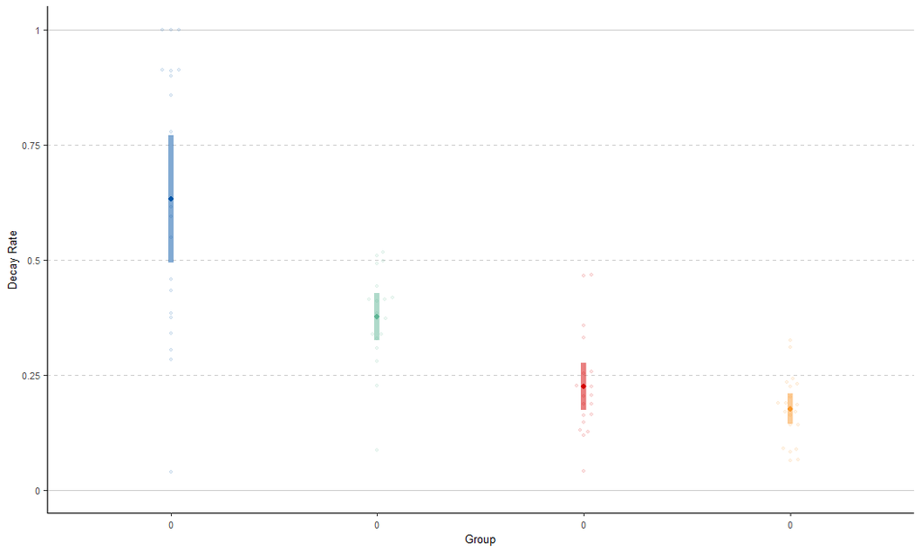

```r
data_per_ppt <- alt_all_washout_rates %>%
  filter(
    experiment %in% c(
      "accel_uncued", "accel_cued_tilt",
      "rot30_uncued", "rot30_cued_tilt"
    )
  ) %>%
  mutate(
    pert = factor(str_split_fixed(experiment, "_", 2)[, 1]),
    cue = factor(str_split_fixed(experiment, "_", 2)[, 2]),
    ppid = factor(ppid)
  )

data_per_group <- data_per_ppt %>%
  group_by(experiment) %>%
  summarise(
    mean_learning_rate = mean(exp_fit_lambda),
    ci_learning_rate = vector_confint(exp_fit_lambda),
    mean_high = mean(exp_fit_N0),
    ci_high = vector_confint(exp_fit_N0),
    .groups = "drop"
  )

p <- data_per_group %>%
  ggplot(
    aes(x = experiment, y = mean_learning_rate, colour = experiment)
  ) +
  theme_classic() +
  labs(
    x = per_group_x_labs,
    y = "Decay Rate"
  ) +
  # remove all x axis labels
  theme(
    legend.position = "none",
    text = element_text(size = text_size)
  ) +
  # colour legend settings
  guides(
    colour = guide_legend(override.aes = list(alpha = 1))
  ) +
  # set colour palette
  scale_colour_manual(values = pallete_list) +
  scale_fill_manual(
    values = pallete_list
  ) +
  # add horizontal lines
  geom_hline(
    yintercept = c(0, 1), linewidth = 0.4,
    colour = "#CCCCCC", linetype = "solid"
  ) +
  geom_hline(
    yintercept = c(0.25, 0.5, 0.75), linewidth = 0.4,
    colour = "#CCCCCC", linetype = "dashed"
  ) +
  # y-axis scale
  scale_y_continuous(
    # limits = c(-35, 5),
    breaks = c(0, 0.25, 0.5, 0.75, 1),
    labels = c(0, 0.25, 0.5, 0.75, 1)
  ) +
  scale_x_discrete(
    labels = c(0, 0, 0, 0)
  ) +
  # add data points
  geom_beeswarm(
    data = data_per_ppt,
    aes(
      y = exp_fit_lambda
    ),
    alpha = 0.1,
    size = 1
  ) +
  geom_linerange(aes(
    ymin = mean_learning_rate - ci_learning_rate,
    ymax = mean_learning_rate + ci_learning_rate
  ), alpha = 0.5, lwd = 2) +
  geom_point()

# save
if (save_plots) {
  ggsave(
    p,
    filename = "../data/figs/paper_figs/fig2_initial_exps_alt_all_washout_learning_rates.pdf", device = "pdf",
    height = 2, width = per_group_fig_width
  )
}

p
```

```r
(temp_ANOVA <- aov_car(
  exp_fit_lambda ~ pert * cue + Error(ppid),
  data_per_ppt,
  include_aov = TRUE
))
```

```
Contrasts set to contr.sum for the following variables: pert, cue
```

```
Anova Table (Type 3 tests)

Response: exp_fit_lambda
    Effect    df  MSE         F  ges p.value
1     pert 1, 76 0.03 64.22 *** .458   <.001
2      cue 1, 76 0.03 16.03 *** .174   <.001
3 pert:cue 1, 76 0.03   7.44 ** .089    .008
---
Signif. codes:  0 ‘***’ 0.001 ‘**’ 0.01 ‘*’ 0.05 ‘+’ 0.1 ‘ ’ 1
```

```r
print("Bayes anovas and bayes factors:")
```

```
[1] "Bayes anovas and bayes factors:"
```

```r
print("")
```

```
[1] ""
```

```r
bf <- anovaBF(exp_fit_lambda ~ pert * cue, data = data.frame(data_per_ppt), progress = FALSE)
print(bf)
```

```
Bayes factor analysis
--------------
[1] pert                  : 24419059    ±0%
[2] cue                   : 10.46332    ±0%
[3] pert + cue            : 1985493796  ±0.9%
[4] pert + cue + pert:cue : 10131609359 ±1.91%

Against denominator:
  Intercept only
---
Bayes factor type: BFlinearModel, JZS
```

```r
print(bayesfactor_inclusion(bf))
```

```
Inclusion Bayes Factors (Model Averaged)

         P(prior) P(posterior) Inclusion BF
pert         0.60         1.00     7.06e+08
cue          0.60         1.00       330.81
cue:pert     0.20         0.83        20.16

* Compared among: all models
*    Priors odds: uniform-equal
```

Pairwise comparisons:

```r
# posthoc tests
# (m1 <- emmeans(temp_ANOVA, ~pert))
# print("Pairwise comparisons:")
# print(summary(pairs(m1), adjust = "tukey")) # Note: default multiplicity correction for pairs summary is Tukey HSD

# Note: default multiplicity correction for pairs summary is Tukey HSD
print("-------------------------- EMMs cue --------------------------")
```

```
[1] "-------------------------- EMMs cue --------------------------"
```

```r
emms_obj <- emmeans(temp_ANOVA, "cue")
```

```
NOTE: Results may be misleading due to involvement in interactions
```

```r
print(pwpm(emms_obj, diffs = FALSE))
```

```
          cued_tilt  uncued
cued_tilt   [0.429]  0.0001
uncued              [0.277]

Row and column labels: cue
Upper triangle: P values
Diagonal: [Estimates] (emmean)
```

```r
# Effect size is Cohen's D
eff_size(emms_obj, edf = temp_ANOVA$anova_table$`den Df`[1], sigma = sigma(temp_ANOVA$lm))
```

```
 contrast           effect.size    SE df lower.CL upper.CL
 cued_tilt - uncued       0.896 0.235 76    0.427     1.36

Results are averaged over the levels of: pert
sigma used for effect sizes: 0.1697
Confidence level used: 0.95
```

```r
print("-------------------------- EMMs perts --------------------------")
```

```
[1] "-------------------------- EMMs perts --------------------------"
```

```r
emms_obj <- emmeans(temp_ANOVA, "pert")
```

```
NOTE: Results may be misleading due to involvement in interactions
```

```r
print(pwpm(emms_obj, diffs = FALSE))
```

```
        accel   rot30
accel [0.505]  <.0001
rot30         [0.200]

Row and column labels: pert
Upper triangle: P values
Diagonal: [Estimates] (emmean)
```

```r
# Effect size is Cohen's D
eff_size(emms_obj, edf = temp_ANOVA$anova_table$`den Df`[1], sigma = sigma(temp_ANOVA$lm))
```

```
 contrast      effect.size    SE df lower.CL upper.CL
 accel - rot30        1.79 0.267 76     1.26     2.32

Results are averaged over the levels of: cue
sigma used for effect sizes: 0.1697
Confidence level used: 0.95
```

```r
print("----------------------------- Full Tukey HSD -----------------------------")
```

```
[1] "----------------------------- Full Tukey HSD -----------------------------"
```

```r
print(TukeyHSD(temp_ANOVA$aov))
```

```
  Tukey multiple comparisons of means
    95% family-wise confidence level

Fit: aov(formula = tmp_formula, data = dat.ret, contrasts = contrasts)

$pert
                  diff        lwr        upr p adj
rot30-accel -0.3082198 -0.3838364 -0.2326031     0

$cue
                       diff        lwr         upr     p adj
uncued-cued_tilt -0.1493744 -0.2249674 -0.07378144 0.0001822

$`pert:cue`
                                       diff          lwr         upr     p adj
rot30:cued_tilt-accel:cued_tilt -0.40791413 -0.548909584 -0.26691867 0.0000000
accel:uncued-accel:cued_tilt    -0.25562326 -0.398461871 -0.11278464 0.0000660
rot30:uncued-accel:cued_tilt    -0.45641134 -0.595718166 -0.31710451 0.0000000
accel:uncued-rot30:cued_tilt     0.15229087  0.009452255  0.29512948 0.0321038
rot30:uncued-rot30:cued_tilt    -0.04849721 -0.187804040  0.09080962 0.7971953
rot30:uncued-accel:uncued       -0.20078808 -0.341960114 -0.05961605 0.0020004
```

```r
print(eff_size(emmeans(temp_ANOVA$aov, c("pert", "cue")),
  edf = temp_ANOVA$anova_table$`den Df`[1],
  sigma = sigma(temp_ANOVA$lm)
))
```

```
 contrast                          effect.size    SE df lower.CL upper.CL
 accel cued_tilt - rot30 cued_tilt       2.403 0.371 76    1.663    3.143
 accel cued_tilt - accel uncued          1.506 0.343 76    0.823    2.189
 accel cued_tilt - rot30 uncued          2.689 0.381 76    1.930    3.448
 rot30 cued_tilt - accel uncued         -0.897 0.329 76   -1.552   -0.243
 rot30 cued_tilt - rot30 uncued          0.286 0.313 76   -0.338    0.910
 accel uncued - rot30 uncued             1.183 0.331 76    0.524    1.842

sigma used for effect sizes: 0.1697
Confidence level used: 0.95
```

## 3.3 Sanity Check: Flick distances

Q: Do participants tend to release the flick early via the trigger? Do flick distances differ across the 4 groups?

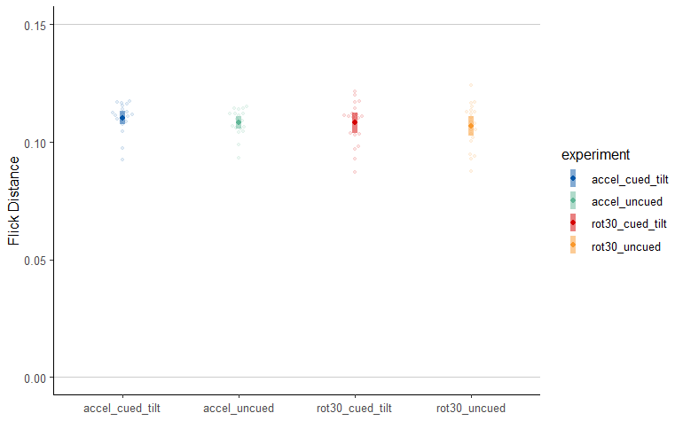

```r
data_per_ppt <- omnibus_df %>%
  filter(!is.na(flick_dist)) %>%
  group_by(experiment, ppid) %>%
  summarise(
    ppt_mean_dist = mean(flick_dist),
    ppt_ci_dist = vector_confint(flick_dist),
    ppt_sd_dist = sd(flick_dist),
    n = n()
  )

data_per_group <- data_per_ppt %>%
  group_by(experiment) %>%
  summarise(
    mean_dist = mean(ppt_mean_dist),
    ci_dist = vector_confint(ppt_mean_dist),
    n = n()
  )

p <- data_per_group %>%
  ggplot(
    aes(x = experiment, y = mean_dist, colour = experiment)
  ) +
  theme_classic() +
  labs(
    x = NULL,
    y = "Flick Distance"
  ) +
  geom_hline(
    yintercept = c(0, 0.15), linewidth = 0.4,
    colour = "#CCCCCC", linetype = "solid"
  ) +
  # add data points
  geom_beeswarm(
    data = data_per_ppt,
    aes(
      y = ppt_mean_dist
    ),
    alpha = 0.1,
    size = 1
  ) +
  geom_linerange(aes(
    ymin = mean_dist - ci_dist,
    ymax = mean_dist + ci_dist
  ), alpha = 0.5, lwd = 2) +
  geom_point() +
  # set colour palette
  scale_colour_manual(values = pallete_list) +
  scale_fill_manual(values = pallete_list)

p
```

### 3.3.1 Within Participant

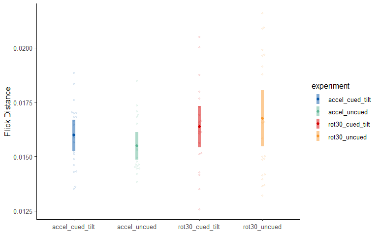

```r
data_per_group <- data_per_ppt %>%
  group_by(experiment) %>%
  summarise(
    mean_dist = mean(ppt_sd_dist),
    ci_dist = vector_confint(ppt_sd_dist),
    n = n()
  )

p <- data_per_group %>%
  ggplot(
    aes(x = experiment, y = mean_dist, colour = experiment)
  ) +
  theme_classic() +
  labs(
    x = NULL,
    y = "Flick Distance"
  ) +
  # geom_hline(
  #   yintercept = c(0, 0.15), linewidth = 0.4,
  #   colour = "#CCCCCC", linetype = "solid"
  # ) +
  # add data points
  geom_beeswarm(
    data = data_per_ppt,
    aes(
      y = ppt_sd_dist
    ),
    alpha = 0.1,
    size = 1
  ) +
  geom_linerange(aes(
    ymin = mean_dist - ci_dist,
    ymax = mean_dist + ci_dist
  ), alpha = 0.5, lwd = 2) +
  geom_point() +
  # set colour palette
  scale_colour_manual(values = pallete_list) +
  scale_fill_manual(values = pallete_list)

p
```

```r
(temp_ANOVA <- aov_car(
  ppt_mean_dist ~ experiment + Error(ppid),
  data_per_ppt,
  include_aov = TRUE
))
```

```
Contrasts set to contr.sum for the following variables: experiment
```

```
Anova Table (Type 3 tests)

Response: ppt_mean_dist
      Effect    df  MSE    F  ges p.value
1 experiment 3, 76 0.00 0.69 .027    .559
---
Signif. codes:  0 ‘***’ 0.001 ‘**’ 0.01 ‘*’ 0.05 ‘+’ 0.1 ‘ ’ 1
```

```r
print("Bayes anovas and bayes factors:")
```

```
[1] "Bayes anovas and bayes factors:"
```

```r
print("")
```

```
[1] ""
```

```r
bf <- anovaBF(ppt_mean_dist ~ experiment, data = data.frame(data_per_ppt), progress = FALSE)
print(bf)
```

```
Bayes factor analysis
--------------
[1] experiment : 0.141823 ±0%

Against denominator:
  Intercept only
---
Bayes factor type: BFlinearModel, JZS
```

```r
print(bayesfactor_inclusion(bf))
```

```
Inclusion Bayes Factors (Model Averaged)

           P(prior) P(posterior) Inclusion BF
experiment     0.50         0.12        0.142

* Compared among: all models
*    Priors odds: uniform-equal
```